# Risk Factor Analysis

## Outcome Variable

**Outcome Variable:** stunted

## Predictor Variables

**Intervention Variable:** nrooms

**Adjustment Set:**

unadjusted

## Stratifying Variables

The analysis was stratified on these variable(s):

- agecat
- studyid

The following strata were considered:

- agecat: 12 months, studyid: ki0047075b-MAL-ED
- agecat: 12 months, studyid: ki1000108-CMC-V-BCS-2002
- agecat: 12 months, studyid: ki1000108-IRC
- agecat: 12 months, studyid: ki1017093b-PROVIDE
- agecat: 12 months, studyid: ki1017093c-NIH-Crypto
- agecat: 12 months, studyid: ki1113344-GMS-Nepal
- agecat: 12 months, studyid: ki1114097-CONTENT
- agecat: 12 months, studyid: ki1135781-COHORTS
- agecat: 18 months, studyid: ki0047075b-MAL-ED
- agecat: 18 months, studyid: ki1000108-CMC-V-BCS-2002
- agecat: 18 months, studyid: ki1000108-IRC
- agecat: 18 months, studyid: ki1017093b-PROVIDE
- agecat: 18 months, studyid: ki1017093c-NIH-Crypto
- agecat: 18 months, studyid: ki1113344-GMS-Nepal
- agecat: 18 months, studyid: ki1114097-CONTENT
- agecat: 24 months, studyid: ki0047075b-MAL-ED
- agecat: 24 months, studyid: ki1000108-CMC-V-BCS-2002
- agecat: 24 months, studyid: ki1000108-IRC
- agecat: 24 months, studyid: ki1017093b-PROVIDE
- agecat: 24 months, studyid: ki1017093c-NIH-Crypto
- agecat: 24 months, studyid: ki1113344-GMS-Nepal
- agecat: 24 months, studyid: ki1114097-CONTENT
- agecat: 24 months, studyid: ki1135781-COHORTS
- agecat: 3 months, studyid: ki0047075b-MAL-ED
- agecat: 3 months, studyid: ki1000108-CMC-V-BCS-2002
- agecat: 3 months, studyid: ki1000108-IRC
- agecat: 3 months, studyid: ki1017093b-PROVIDE
- agecat: 3 months, studyid: ki1017093c-NIH-Crypto
- agecat: 3 months, studyid: ki1113344-GMS-Nepal
- agecat: 3 months, studyid: ki1114097-CONTENT
- agecat: 3 months, studyid: ki1135781-COHORTS
- agecat: 6 months, studyid: ki0047075b-MAL-ED
- agecat: 6 months, studyid: ki1000108-CMC-V-BCS-2002
- agecat: 6 months, studyid: ki1000108-IRC
- agecat: 6 months, studyid: ki1017093b-PROVIDE
- agecat: 6 months, studyid: ki1017093c-NIH-Crypto
- agecat: 6 months, studyid: ki1113344-GMS-Nepal
- agecat: 6 months, studyid: ki1114097-CONTENT
- agecat: 6 months, studyid: ki1135781-COHORTS
- agecat: 9 months, studyid: ki0047075b-MAL-ED
- agecat: 9 months, studyid: ki1000108-CMC-V-BCS-2002
- agecat: 9 months, studyid: ki1000108-IRC
- agecat: 9 months, studyid: ki1017093b-PROVIDE
- agecat: 9 months, studyid: ki1017093c-NIH-Crypto
- agecat: 9 months, studyid: ki1113344-GMS-Nepal
- agecat: 9 months, studyid: ki1114097-CONTENT
- agecat: 9 months, studyid: ki1135781-COHORTS
- agecat: Birth, studyid: ki0047075b-MAL-ED
- agecat: Birth, studyid: ki1000108-CMC-V-BCS-2002
- agecat: Birth, studyid: ki1000108-IRC
- agecat: Birth, studyid: ki1017093c-NIH-Crypto
- agecat: Birth, studyid: ki1114097-CONTENT
- agecat: Birth, studyid: ki1135781-COHORTS

### Dropped Strata

Some strata were dropped due to rare outcomes:

- agecat: 12 months, studyid: ki1017093b-PROVIDE
- agecat: 12 months, studyid: ki1114097-CONTENT
- agecat: 18 months, studyid: ki1017093b-PROVIDE
- agecat: 18 months, studyid: ki1114097-CONTENT
- agecat: 24 months, studyid: ki1017093b-PROVIDE
- agecat: 24 months, studyid: ki1114097-CONTENT
- agecat: 3 months, studyid: ki1000108-CMC-V-BCS-2002
- agecat: 3 months, studyid: ki1017093b-PROVIDE
- agecat: 3 months, studyid: ki1114097-CONTENT
- agecat: 6 months, studyid: ki1000108-CMC-V-BCS-2002
- agecat: 6 months, studyid: ki1000108-IRC
- agecat: 6 months, studyid: ki1017093b-PROVIDE
- agecat: 6 months, studyid: ki1114097-CONTENT
- agecat: 9 months, studyid: ki1017093b-PROVIDE
- agecat: 9 months, studyid: ki1114097-CONTENT
- agecat: Birth, studyid: ki1000108-CMC-V-BCS-2002
- agecat: Birth, studyid: ki1000108-IRC
- agecat: Birth, studyid: ki1017093c-NIH-Crypto
- agecat: Birth, studyid: ki1114097-CONTENT

## Methods Detail

We’re interested in the causal parameters $E[Y_a]$ for all values of $a \in \mathcal{A}$. These parameters represent the mean outcome if, possibly contrary to fact, we intervened to set all units to have $A=a$. Under the randomization and positivity assumptions, these are identified by the statistical parameters $\psi_a=E_W[E_{Y|A,W}(Y|A=a,W)]$. In addition, we’re interested in the mean of $Y$, $E[Y]$ under no intervention (the observed mean). We will estimate these parameters by using SuperLearner to fit the relevant likelihood factors – $E_{Y|A,W}(Y|A=a,W)$ and $p(A=a|W)$, and then updating our likelihood fit using a joint TMLE.

For unadjusted analyses ($W=\{\}$), initial likelihoods were estimated using Lrnr_glm to estimate the simple $E(Y|A)$ and Lrnr_mean to estimate $p(A)$. For adjusted analyses, a small library containing Lrnr_glmnet, Lrnr_xgboost, and Lrnr_mean was used.

Having estimated these parameters, we will then use the delta method to estimate relative risks and attributable risks relative to a prespecified baseline level of $A$.

# Results Detail

## Results Plots

[figure not shown]

[figure not shown]

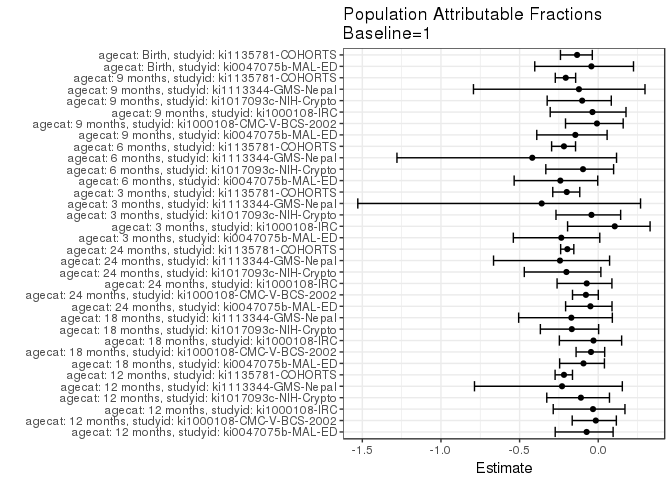

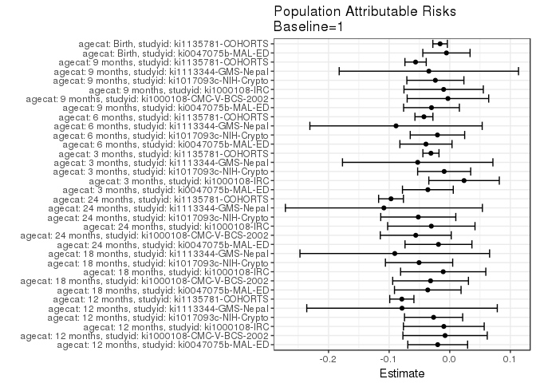

## Data Summary

| agecat | studyid | A | n | nA | nAY0 | nAY1 |
| --- | --- | --- | --- | --- | --- | --- |
| 12 months | ki0047075b-MAL-ED | 1 | 1615 | 325 | 231 | 94 |
| 12 months | ki0047075b-MAL-ED | 2 | 1615 | 291 | 192 | 99 |
| 12 months | ki0047075b-MAL-ED | 3 | 1615 | 290 | 215 | 75 |
| 12 months | ki0047075b-MAL-ED | 4+ | 1615 | 709 | 542 | 167 |
| 12 months | ki1000108-CMC-V-BCS-2002 | 1 | 368 | 200 | 99 | 101 |
| 12 months | ki1000108-CMC-V-BCS-2002 | 2 | 368 | 105 | 48 | 57 |
| 12 months | ki1000108-CMC-V-BCS-2002 | 3 | 368 | 49 | 30 | 19 |
| 12 months | ki1000108-CMC-V-BCS-2002 | 4+ | 368 | 14 | 8 | 6 |
| 12 months | ki1000108-IRC | 1 | 404 | 184 | 128 | 56 |
| 12 months | ki1000108-IRC | 2 | 404 | 169 | 119 | 50 |
| 12 months | ki1000108-IRC | 3 | 404 | 34 | 27 | 7 |
| 12 months | ki1000108-IRC | 4+ | 404 | 17 | 11 | 6 |
| 12 months | ki1017093b-PROVIDE | 1 | 153 | 105 | 71 | 34 |
| 12 months | ki1017093b-PROVIDE | 2 | 153 | 25 | 20 | 5 |
| 12 months | ki1017093b-PROVIDE | 3 | 153 | 16 | 13 | 3 |
| 12 months | ki1017093b-PROVIDE | 4+ | 153 | 7 | 5 | 2 |
| 12 months | ki1017093c-NIH-Crypto | 1 | 706 | 331 | 242 | 89 |
| 12 months | ki1017093c-NIH-Crypto | 2 | 706 | 183 | 131 | 52 |
| 12 months | ki1017093c-NIH-Crypto | 3 | 706 | 102 | 90 | 12 |
| 12 months | ki1017093c-NIH-Crypto | 4+ | 706 | 90 | 72 | 18 |
| 12 months | ki1113344-GMS-Nepal | 1 | 558 | 38 | 22 | 16 |
| 12 months | ki1113344-GMS-Nepal | 2 | 558 | 119 | 70 | 49 |
| 12 months | ki1113344-GMS-Nepal | 3 | 558 | 136 | 98 | 38 |
| 12 months | ki1113344-GMS-Nepal | 4+ | 558 | 265 | 177 | 88 |
| 12 months | ki1114097-CONTENT | 1 | 215 | 44 | 34 | 10 |
| 12 months | ki1114097-CONTENT | 2 | 215 | 54 | 47 | 7 |
| 12 months | ki1114097-CONTENT | 3 | 215 | 39 | 37 | 2 |
| 12 months | ki1114097-CONTENT | 4+ | 215 | 78 | 71 | 7 |
| 12 months | ki1135781-COHORTS | 1 | 3874 | 2451 | 1367 | 1084 |
| 12 months | ki1135781-COHORTS | 2 | 3874 | 1202 | 916 | 286 |

[output cut: 194 more lines]

## Results Table

### Parameter: TSM

| agecat | studyid | intervention_level | baseline_level | estimate | ci_lower | ci_upper |
| --- | --- | --- | --- | --- | --- | --- |
| 12 months | ki0047075b-MAL-ED | 1 | NA | 0.2892308 | 0.2399216 | 0.3385399 |
| 12 months | ki0047075b-MAL-ED | 2 | NA | 0.3402062 | 0.2857545 | 0.3946579 |
| 12 months | ki0047075b-MAL-ED | 3 | NA | 0.2586207 | 0.2082085 | 0.3090329 |
| 12 months | ki0047075b-MAL-ED | 4+ | NA | 0.2355430 | 0.2042987 | 0.2667873 |
| 12 months | ki1000108-CMC-V-BCS-2002 | 1 | NA | 0.5050000 | 0.4356139 | 0.5743861 |
| 12 months | ki1000108-CMC-V-BCS-2002 | 2 | NA | 0.5428571 | 0.4474429 | 0.6382714 |
| 12 months | ki1000108-CMC-V-BCS-2002 | 3 | NA | 0.3877551 | 0.2511452 | 0.5243650 |
| 12 months | ki1000108-CMC-V-BCS-2002 | 4+ | NA | 0.4285714 | 0.1689936 | 0.6881492 |
| 12 months | ki1000108-IRC | 1 | NA | 0.3043478 | 0.2377809 | 0.3709148 |
| 12 months | ki1000108-IRC | 2 | NA | 0.2958580 | 0.2269587 | 0.3647573 |
| 12 months | ki1000108-IRC | 3 | NA | 0.2058824 | 0.0698010 | 0.3419638 |
| 12 months | ki1000108-IRC | 4+ | NA | 0.3529412 | 0.1254918 | 0.5803906 |
| 12 months | ki1017093c-NIH-Crypto | 1 | NA | 0.2688822 | 0.2210834 | 0.3166809 |
| 12 months | ki1017093c-NIH-Crypto | 2 | NA | 0.2841530 | 0.2187622 | 0.3495438 |
| 12 months | ki1017093c-NIH-Crypto | 3 | NA | 0.1176471 | 0.0550769 | 0.1802173 |
| 12 months | ki1017093c-NIH-Crypto | 4+ | NA | 0.2000000 | 0.1173021 | 0.2826979 |
| 12 months | ki1113344-GMS-Nepal | 1 | NA | 0.4210526 | 0.2639319 | 0.5781734 |
| 12 months | ki1113344-GMS-Nepal | 2 | NA | 0.4117647 | 0.3232604 | 0.5002690 |
| 12 months | ki1113344-GMS-Nepal | 3 | NA | 0.2794118 | 0.2039314 | 0.3548921 |
| 12 months | ki1113344-GMS-Nepal | 4+ | NA | 0.3320755 | 0.2753214 | 0.3888295 |
| 12 months | ki1135781-COHORTS | 1 | NA | 0.4422685 | 0.4226037 | 0.4619332 |
| 12 months | ki1135781-COHORTS | 2 | NA | 0.2379368 | 0.2138611 | 0.2620124 |
| 12 months | ki1135781-COHORTS | 3 | NA | 0.2167832 | 0.1492387 | 0.2843277 |
| 12 months | ki1135781-COHORTS | 4+ | NA | 0.0769232 | 0.0177801 | 0.1360663 |
| 18 months | ki0047075b-MAL-ED | 1 | NA | 0.4230769 | 0.3682391 | 0.4779147 |
| 18 months | ki0047075b-MAL-ED | 2 | NA | 0.4981818 | 0.4390679 | 0.5572957 |
| 18 months | ki0047075b-MAL-ED | 3 | NA | 0.3727599 | 0.3160030 | 0.4295167 |
| 18 months | ki0047075b-MAL-ED | 4+ | NA | 0.3308824 | 0.2955053 | 0.3662594 |
| 18 months | ki1000108-CMC-V-BCS-2002 | 1 | NA | 0.7200000 | 0.6576886 | 0.7823114 |
| 18 months | ki1000108-CMC-V-BCS-2002 | 2 | NA | 0.6857143 | 0.5967990 | 0.7746296 |

[output cut: 106 more lines]

### Parameter: E(Y)

| agecat | studyid | intervention_level | baseline_level | estimate | ci_lower | ci_upper |
| --- | --- | --- | --- | --- | --- | --- |
| 12 months | ki0047075b-MAL-ED | NA | NA | 0.2693498 | 0.2674562 | 0.2712435 |
| 12 months | ki1000108-CMC-V-BCS-2002 | NA | NA | 0.4972826 | 0.4922685 | 0.5022967 |
| 12 months | ki1000108-IRC | NA | NA | 0.2945545 | 0.2917087 | 0.2974002 |
| 12 months | ki1017093c-NIH-Crypto | NA | NA | 0.2422096 | 0.2379960 | 0.2464232 |
| 12 months | ki1113344-GMS-Nepal | NA | NA | 0.3422939 | 0.3381708 | 0.3464170 |
| 12 months | ki1135781-COHORTS | NA | NA | 0.3631905 | 0.3598478 | 0.3665332 |
| 18 months | ki0047075b-MAL-ED | NA | NA | 0.3868047 | 0.3836974 | 0.3899119 |
| 18 months | ki1000108-CMC-V-BCS-2002 | NA | NA | 0.6883469 | 0.6836451 | 0.6930487 |
| 18 months | ki1000108-IRC | NA | NA | 0.3573201 | 0.3527330 | 0.3619072 |
| 18 months | ki1017093c-NIH-Crypto | NA | NA | 0.3012618 | 0.2965543 | 0.3059694 |
| 18 months | ki1113344-GMS-Nepal | NA | NA | 0.5309091 | 0.5278222 | 0.5339960 |
| 24 months | ki0047075b-MAL-ED | NA | NA | 0.3754197 | 0.3726258 | 0.3782137 |
| 24 months | ki1000108-CMC-V-BCS-2002 | NA | NA | 0.7150538 | 0.7085290 | 0.7215786 |
| 24 months | ki1000108-IRC | NA | NA | 0.4152334 | 0.4103592 | 0.4201077 |
| 24 months | ki1017093c-NIH-Crypto | NA | NA | 0.2568093 | 0.2497884 | 0.2638303 |
| 24 months | ki1113344-GMS-Nepal | NA | NA | 0.4468938 | 0.4433354 | 0.4504522 |
| 24 months | ki1135781-COHORTS | NA | NA | 0.4934649 | 0.4894738 | 0.4974561 |
| 3 months | ki0047075b-MAL-ED | NA | NA | 0.1538008 | 0.1524363 | 0.1551654 |
| 3 months | ki1000108-IRC | NA | NA | 0.2246914 | 0.2203269 | 0.2290558 |
| 3 months | ki1017093c-NIH-Crypto | NA | NA | 0.2142857 | 0.2125359 | 0.2160355 |
| 3 months | ki1113344-GMS-Nepal | NA | NA | 0.1471103 | 0.1444695 | 0.1497511 |
| 3 months | ki1135781-COHORTS | NA | NA | 0.1550128 | 0.1538202 | 0.1562054 |
| 6 months | ki0047075b-MAL-ED | NA | NA | 0.1631079 | 0.1615225 | 0.1646934 |
| 6 months | ki1017093c-NIH-Crypto | NA | NA | 0.2097902 | 0.2071301 | 0.2124503 |
| 6 months | ki1113344-GMS-Nepal | NA | NA | 0.2113677 | 0.2091851 | 0.2135502 |
| 6 months | ki1135781-COHORTS | NA | NA | 0.1954857 | 0.1938630 | 0.1971084 |
| 9 months | ki0047075b-MAL-ED | NA | NA | 0.2069597 | 0.2056571 | 0.2082623 |
| 9 months | ki1000108-CMC-V-BCS-2002 | NA | NA | 0.3688525 | 0.3672140 | 0.3704909 |
| 9 months | ki1000108-IRC | NA | NA | 0.2740741 | 0.2718095 | 0.2763387 |
| 9 months | ki1017093c-NIH-Crypto | NA | NA | 0.2322946 | 0.2294335 | 0.2351557 |
| 9 months | ki1113344-GMS-Nepal | NA | NA | 0.2813067 | 0.2800692 | 0.2825443 |
| 9 months | ki1135781-COHORTS | NA | NA | 0.2729998 | 0.2706891 | 0.2753104 |
| Birth | ki0047075b-MAL-ED | NA | NA | 0.1260073 | 0.1253287 | 0.1266859 |
| Birth | ki1135781-COHORTS | NA | NA | 0.1184735 | 0.1178501 | 0.1190968 |

### Parameter: RR

| agecat | studyid | intervention_level | baseline_level | estimate | ci_lower | ci_upper |
| --- | --- | --- | --- | --- | --- | --- |
| 12 months | ki0047075b-MAL-ED | 2 | 1 | 1.1762448 | 0.9309819 | 1.4861211 |
| 12 months | ki0047075b-MAL-ED | 3 | 1 | 0.8941673 | 0.6901652 | 1.1584692 |
| 12 months | ki0047075b-MAL-ED | 4+ | 1 | 0.8143775 | 0.6561663 | 1.0107357 |
| 12 months | ki1000108-CMC-V-BCS-2002 | 2 | 1 | 1.0749646 | 0.8600144 | 1.3436391 |
| 12 months | ki1000108-CMC-V-BCS-2002 | 3 | 1 | 0.7678319 | 0.5260608 | 1.1207180 |
| 12 months | ki1000108-CMC-V-BCS-2002 | 4+ | 1 | 0.8486563 | 0.4560416 | 1.5792804 |
| 12 months | ki1000108-IRC | 2 | 1 | 0.9721048 | 0.7062559 | 1.3380246 |
| 12 months | ki1000108-IRC | 3 | 1 | 0.6764706 | 0.3371992 | 1.3570983 |
| 12 months | ki1000108-IRC | 4+ | 1 | 1.1596639 | 0.5871854 | 2.2902823 |
| 12 months | ki1017093c-NIH-Crypto | 2 | 1 | 1.0567938 | 0.7901352 | 1.4134454 |
| 12 months | ki1017093c-NIH-Crypto | 3 | 1 | 0.4375413 | 0.2497353 | 0.7665812 |
| 12 months | ki1017093c-NIH-Crypto | 4+ | 1 | 0.7438202 | 0.4742410 | 1.1666399 |
| 12 months | ki1113344-GMS-Nepal | 2 | 1 | 0.9779412 | 0.6357544 | 1.5043058 |
| 12 months | ki1113344-GMS-Nepal | 3 | 1 | 0.6636029 | 0.4186372 | 1.0519106 |
| 12 months | ki1113344-GMS-Nepal | 4+ | 1 | 0.7886792 | 0.5231782 | 1.1889159 |
| 12 months | ki1135781-COHORTS | 2 | 1 | 0.5379917 | 0.4816992 | 0.6008628 |
| 12 months | ki1135781-COHORTS | 3 | 1 | 0.4901621 | 0.3578104 | 0.6714697 |
| 12 months | ki1135781-COHORTS | 4+ | 1 | 0.1739287 | 0.0805197 | 0.3756994 |
| 18 months | ki0047075b-MAL-ED | 2 | 1 | 1.1775207 | 0.9877582 | 1.4037391 |
| 18 months | ki0047075b-MAL-ED | 3 | 1 | 0.8810688 | 0.7213871 | 1.0760965 |
| 18 months | ki0047075b-MAL-ED | 4+ | 1 | 0.7820856 | 0.6611237 | 0.9251791 |
| 18 months | ki1000108-CMC-V-BCS-2002 | 2 | 1 | 0.9523810 | 0.8149028 | 1.1130523 |
| 18 months | ki1000108-CMC-V-BCS-2002 | 3 | 1 | 0.8169935 | 0.6390294 | 1.0445190 |
| 18 months | ki1000108-CMC-V-BCS-2002 | 4+ | 1 | 0.8547009 | 0.5510367 | 1.3257076 |
| 18 months | ki1000108-IRC | 2 | 1 | 0.9483352 | 0.7162217 | 1.2556723 |
| 18 months | ki1000108-IRC | 3 | 1 | 0.6985075 | 0.3852204 | 1.2665805 |
| 18 months | ki1000108-IRC | 4+ | 1 | 1.4381036 | 0.8832052 | 2.3416324 |
| 18 months | ki1017093c-NIH-Crypto | 2 | 1 | 0.8911477 | 0.6782613 | 1.1708529 |
| 18 months | ki1017093c-NIH-Crypto | 3 | 1 | 0.5868489 | 0.3815426 | 0.9026295 |
| 18 months | ki1017093c-NIH-Crypto | 4+ | 1 | 0.5947502 | 0.3829968 | 0.9235790 |

[output cut: 72 more lines]

### Parameter: PAR

| agecat | studyid | intervention_level | baseline_level | estimate | ci_lower | ci_upper |
| --- | --- | --- | --- | --- | --- | --- |
| 12 months | ki0047075b-MAL-ED | 1 | NA | -0.0198809 | -0.0692264 | 0.0294646 |
| 12 months | ki1000108-CMC-V-BCS-2002 | 1 | NA | -0.0077174 | -0.0772844 | 0.0618496 |
| 12 months | ki1000108-IRC | 1 | NA | -0.0097934 | -0.0764211 | 0.0568344 |
| 12 months | ki1017093c-NIH-Crypto | 1 | NA | -0.0266725 | -0.0746567 | 0.0213116 |
| 12 months | ki1113344-GMS-Nepal | 1 | NA | -0.0787587 | -0.2359336 | 0.0784161 |
| 12 months | ki1135781-COHORTS | 1 | NA | -0.0790780 | -0.0990248 | -0.0591311 |
| 18 months | ki0047075b-MAL-ED | 1 | NA | -0.0362723 | -0.0911980 | 0.0186535 |
| 18 months | ki1000108-CMC-V-BCS-2002 | 1 | NA | -0.0316531 | -0.0941417 | 0.0308354 |
| 18 months | ki1000108-IRC | 1 | NA | -0.0108118 | -0.0811179 | 0.0594944 |
| 18 months | ki1017093c-NIH-Crypto | 1 | NA | -0.0506545 | -0.1061495 | 0.0048404 |
| 18 months | ki1113344-GMS-Nepal | 1 | NA | -0.0907125 | -0.2471545 | 0.0657294 |
| 24 months | ki0047075b-MAL-ED | 1 | NA | -0.0186200 | -0.0738201 | 0.0365801 |
| 24 months | ki1000108-CMC-V-BCS-2002 | 1 | NA | -0.0560905 | -0.1146099 | 0.0024289 |
| 24 months | ki1000108-IRC | 1 | NA | -0.0304188 | -0.1024893 | 0.0416518 |
| 24 months | ki1017093c-NIH-Crypto | 1 | NA | -0.0519464 | -0.1138725 | 0.0099797 |
| 24 months | ki1113344-GMS-Nepal | 1 | NA | -0.1086618 | -0.2711826 | 0.0538591 |
| 24 months | ki1135781-COHORTS | 1 | NA | -0.0968913 | -0.1173754 | -0.0764071 |
| 3 months | ki0047075b-MAL-ED | 1 | NA | -0.0361102 | -0.0780216 | 0.0058013 |
| 3 months | ki1000108-IRC | 1 | NA | 0.0236044 | -0.0345449 | 0.0817537 |
| 3 months | ki1017093c-NIH-Crypto | 1 | NA | -0.0092100 | -0.0529811 | 0.0345611 |
| 3 months | ki1113344-GMS-Nepal | 1 | NA | -0.0528897 | -0.1769855 | 0.0712061 |
| 3 months | ki1135781-COHORTS | 1 | NA | -0.0310407 | -0.0443189 | -0.0177625 |
| 6 months | ki0047075b-MAL-ED | 1 | NA | -0.0392730 | -0.0822747 | 0.0037287 |
| 6 months | ki1017093c-NIH-Crypto | 1 | NA | -0.0202983 | -0.0652124 | 0.0246159 |
| 6 months | ki1113344-GMS-Nepal | 1 | NA | -0.0886323 | -0.2307883 | 0.0535236 |
| 6 months | ki1135781-COHORTS | 1 | NA | -0.0426095 | -0.0574273 | -0.0277918 |
| 9 months | ki0047075b-MAL-ED | 1 | NA | -0.0301224 | -0.0761104 | 0.0158657 |
| 9 months | ki1000108-CMC-V-BCS-2002 | 1 | NA | -0.0030068 | -0.0702677 | 0.0642540 |
| 9 months | ki1000108-IRC | 1 | NA | -0.0100789 | -0.0755434 | 0.0553855 |
| 9 months | ki1017093c-NIH-Crypto | 1 | NA | -0.0237295 | -0.0707958 | 0.0233369 |
| 9 months | ki1113344-GMS-Nepal | 1 | NA | -0.0344828 | -0.1824139 | 0.1134484 |
| 9 months | ki1135781-COHORTS | 1 | NA | -0.0563951 | -0.0739799 | -0.0388104 |
| Birth | ki0047075b-MAL-ED | 1 | NA | -0.0054806 | -0.0444617 | 0.0335006 |
| Birth | ki1135781-COHORTS | 1 | NA | -0.0159265 | -0.0279026 | -0.0039504 |

### Parameter: PAF

| agecat | studyid | intervention_level | baseline_level | estimate | ci_lower | ci_upper |
| --- | --- | --- | --- | --- | --- | --- |
| 12 months | ki0047075b-MAL-ED | 1 | NA | -0.0738108 | -0.2735935 | 0.0946329 |
| 12 months | ki1000108-CMC-V-BCS-2002 | 1 | NA | -0.0155191 | -0.1655203 | 0.1151770 |
| 12 months | ki1000108-IRC | 1 | NA | -0.0332481 | -0.2861336 | 0.1699139 |
| 12 months | ki1017093c-NIH-Crypto | 1 | NA | -0.1101217 | -0.3272210 | 0.0714657 |
| 12 months | ki1113344-GMS-Nepal | 1 | NA | -0.2300909 | -0.7868320 | 0.1531808 |
| 12 months | ki1135781-COHORTS | 1 | NA | -0.2177314 | -0.2742981 | -0.1636757 |
| 18 months | ki0047075b-MAL-ED | 1 | NA | -0.0937741 | -0.2454532 | 0.0394325 |
| 18 months | ki1000108-CMC-V-BCS-2002 | 1 | NA | -0.0459843 | -0.1408471 | 0.0409907 |
| 18 months | ki1000108-IRC | 1 | NA | -0.0302579 | -0.2470927 | 0.1488753 |
| 18 months | ki1017093c-NIH-Crypto | 1 | NA | -0.1681413 | -0.3679511 | 0.0024833 |
| 18 months | ki1113344-GMS-Nepal | 1 | NA | -0.1708626 | -0.5059537 | 0.0896670 |
| 24 months | ki0047075b-MAL-ED | 1 | NA | -0.0495978 | -0.2074526 | 0.0876201 |
| 24 months | ki1000108-CMC-V-BCS-2002 | 1 | NA | -0.0784424 | -0.1635563 | 0.0004454 |
| 24 months | ki1000108-IRC | 1 | NA | -0.0732570 | -0.2617170 | 0.0870531 |
| 24 months | ki1017093c-NIH-Crypto | 1 | NA | -0.2022762 | -0.4701386 | 0.0167810 |
| 24 months | ki1113344-GMS-Nepal | 1 | NA | -0.2431490 | -0.6656633 | 0.0721898 |
| 24 months | ki1135781-COHORTS | 1 | NA | -0.1963489 | -0.2389387 | -0.1552231 |
| 3 months | ki0047075b-MAL-ED | 1 | NA | -0.2347852 | -0.5397937 | 0.0098060 |
| 3 months | ki1000108-IRC | 1 | NA | 0.1050526 | -0.1948521 | 0.3296819 |
| 3 months | ki1017093c-NIH-Crypto | 1 | NA | -0.0429799 | -0.2686374 | 0.1425389 |
| 3 months | ki1113344-GMS-Nepal | 1 | NA | -0.3595238 | -1.5287691 | 0.2690891 |
| 3 months | ki1135781-COHORTS | 1 | NA | -0.2002460 | -0.2891989 | -0.1174308 |
| 6 months | ki0047075b-MAL-ED | 1 | NA | -0.2407792 | -0.5346407 | -0.0031879 |
| 6 months | ki1017093c-NIH-Crypto | 1 | NA | -0.0967552 | -0.3332628 | 0.0977984 |
| 6 months | ki1113344-GMS-Nepal | 1 | NA | -0.4193277 | -1.2798122 | 0.1163784 |
| 6 months | ki1135781-COHORTS | 1 | NA | -0.2179676 | -0.2964091 | -0.1442723 |
| 9 months | ki0047075b-MAL-ED | 1 | NA | -0.1455470 | -0.3908039 | 0.0564609 |
| 9 months | ki1000108-CMC-V-BCS-2002 | 1 | NA | -0.0081519 | -0.2080371 | 0.1586598 |
| 9 months | ki1000108-IRC | 1 | NA | -0.0367745 | -0.3053997 | 0.1765731 |
| 9 months | ki1017093c-NIH-Crypto | 1 | NA | -0.1021525 | -0.3246837 | 0.0829960 |
| 9 months | ki1113344-GMS-Nepal | 1 | NA | -0.1225806 | -0.7933459 | 0.2972983 |
| 9 months | ki1135781-COHORTS | 1 | NA | -0.2065758 | -0.2730061 | -0.1436121 |
| Birth | ki0047075b-MAL-ED | 1 | NA | -0.0434940 | -0.4036006 | 0.2242239 |
| Birth | ki1135781-COHORTS | 1 | NA | -0.1344312 | -0.2402016 | -0.0376813 |